# EDA

Hubert Ruczyński

9 01 2022

# Languages

```r
Languages <- as.data.frame(table(contr$Language))
Languages
```

```
##          Var1 Freq
## 1   Bulgarian    1
## 2    Croatian    2
## 3      Danish   10
## 4       Dutch   17
## 5     English  788
## 6     Finnish    6
## 7      French   76
## 8      German  177
## 9       Greek    5
## 10  Hungarian    5
## 11    Italian   31
## 12    Latvian    2
## 13 Lithuanian    3
## 14     Polish    5
## 15 Portuguese   14
## 16   Romanian    7
## 17     Slovak    1
## 18  Slovenian    4
## 19    Spanish   51
## 20    Swedish   11
```

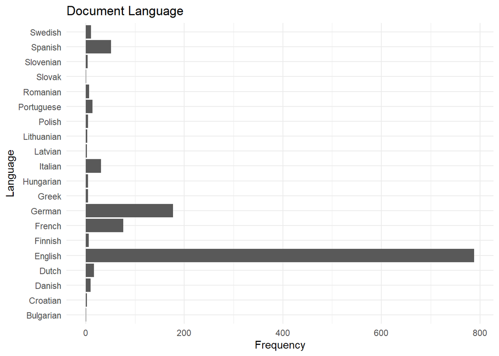

# User Type

Despite anonymous users, most interested faction were people connected to business (organization + association), Academic/Research Institutions, Non governmental organisations and regular EU Citizens.

```r
UType <- as.data.frame(table(contr$User.type))
UType
```

```
##                                   Var1 Freq
## 1                                       460
## 2        Academic/Research Institution  112
## 3                 Business Association  111
## 4        Company/Business organisation  150
## 5                Consumer Organisation    7
## 6           Environmental Organisation    1
## 7                           EU Citizen  115
## 8  NGO (Non-governmental organisation)  117
## 9                       Non-EU Citizen   17
## 10                               Other   62
## 11                    Public authority   43
## 12                         Trade Union   21
```

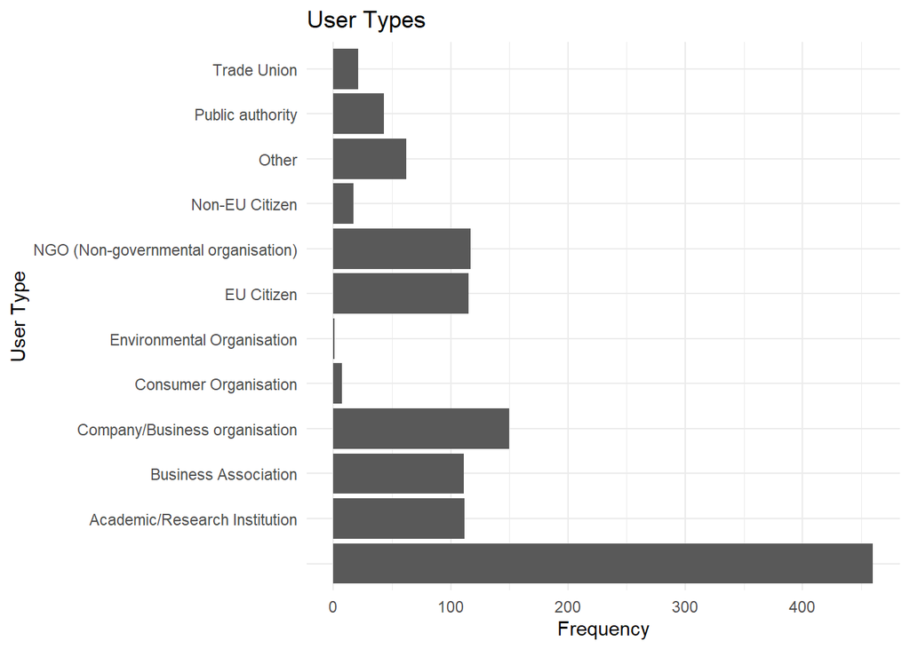

# Organization size

Large organisations were the most interested, however the medium ones were the least interested group with small and micro almost doubling their frequency.

```r
OrgSize <- as.data.frame(table(contr$Organisation.size))
OrgSize
```

```
##                       Var1 Freq
## 1                           592
## 2      Large (250 or more)  256
## 3 Medium (< 250 employees)   89
## 4   Micro (< 10 employees)  151
## 5   Small (< 50 employees)  128
```

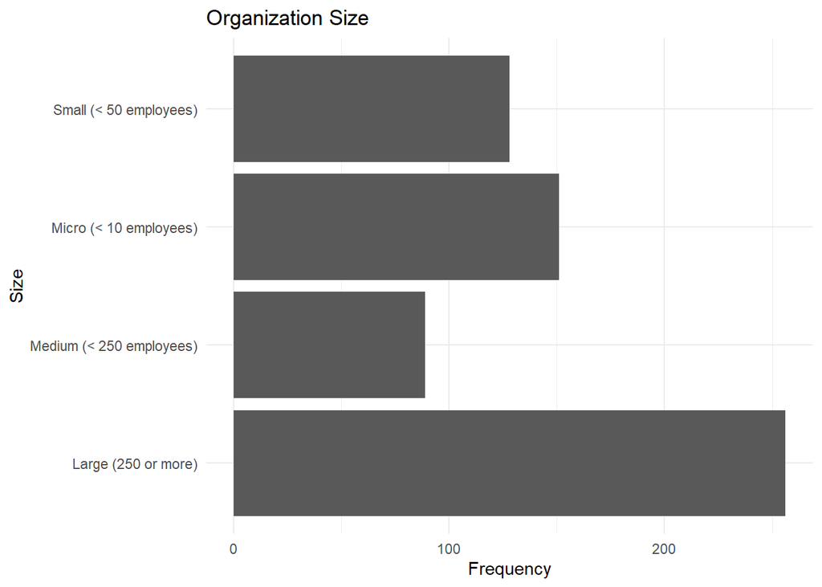

# Country of origin

The most interested countries were the leading European countries such as Belgium, Germany and France. One of the biggest faction were also people from the USA and surprisingly even people outside of Europe were involved in this questionnaire.

```r
Country <- as.data.frame(table(contr$Country))
Country
```

```
##              Var1 Freq
## 1                  460
## 2         Albania    1
## 3         Austria   16
## 4         Belgium  131
## 5          Brazil    1
## 6        Bulgaria    3
## 7          Canada    4
## 8           China    1
## 9      Costa Rica    1
## 10  Côte d’Ivoire    1
## 11        Croatia    1
## 12 Czech Republic    5
## 13        Denmark   17
## 14        Finland   19
```

[output cut: 25 more lines]

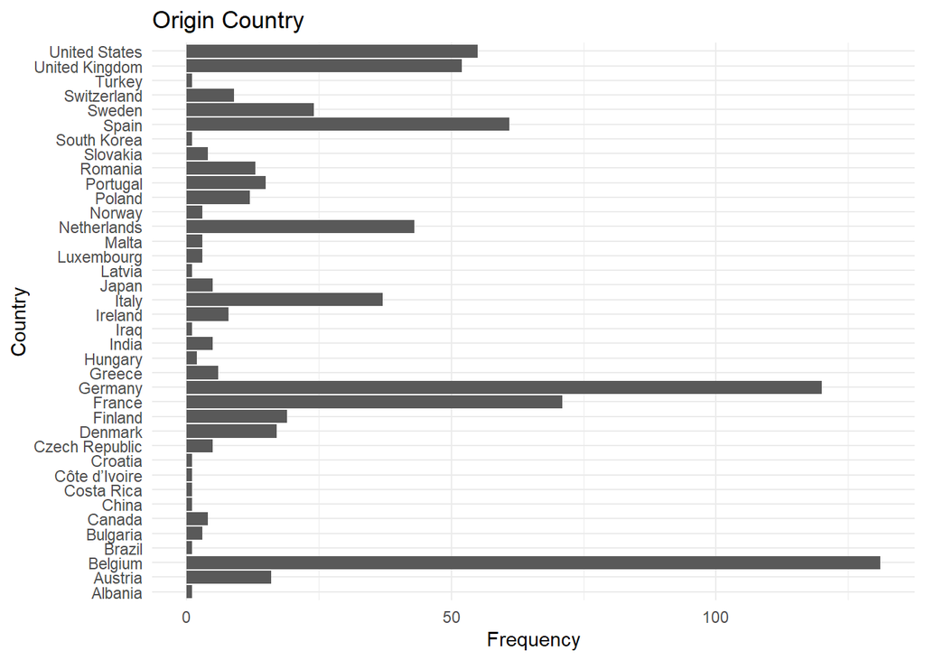

# Privacy

About 60% of correspondents agreed to use their personal information.

```r
Privacy <- as.data.frame(table(contr$Publication.privacy.settings))
Privacy
```

```
##                                                           Var1 Freq
## 1            The feedback can be published in an anonymous way  460
## 2 The feedback can be published with your personal information  756
```

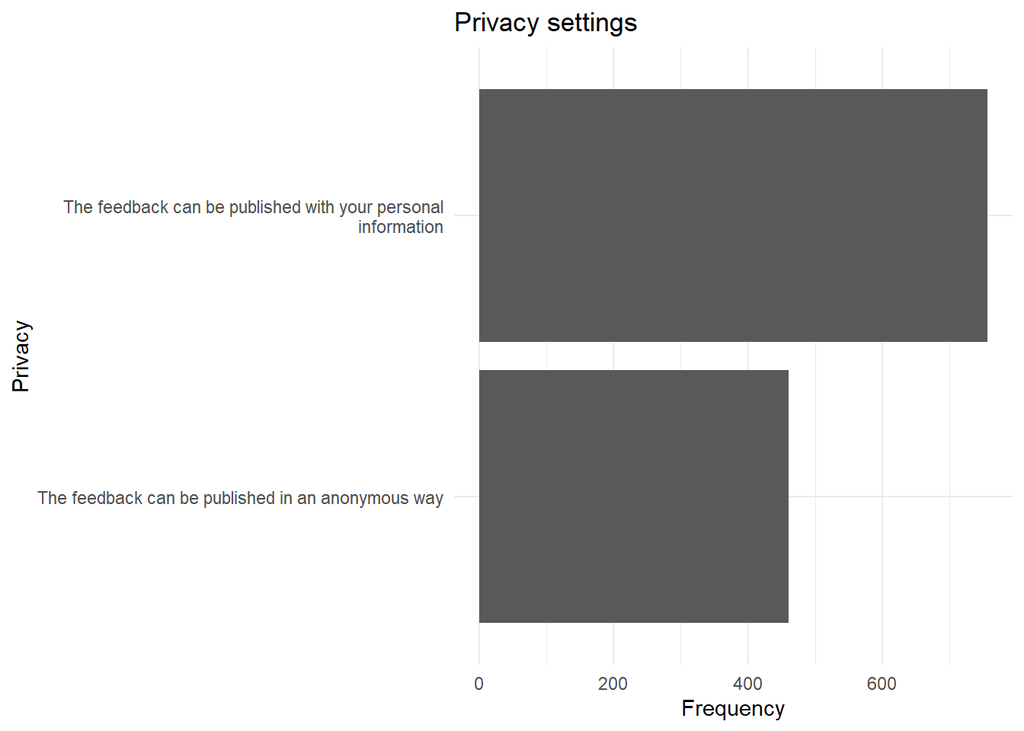

# Importance Questions

During 1-5 questions analysis we found out which questions are most commonly supported and which ones are more disagreed upon. To make a brief selection we counted sum of agreement points (1-5) and focused on top 3 questions in each category.

```r
Questions <- contr[,-c(1,2,3,4,5,6,7,8,9,10,11,12,19,26,30,36,43,45,47,49,56,57,
                       58,59,60,61,62,63,64,65,66,67,68,69,70,71,72,73)]
Questions <- Questions[,-c(27,28,29,30)]
Q <- as.data.frame(Questions)
colnames(Q) <- 1:31
Q[Q == "5 - Very important"] <- 5
Q[Q == "4 - Important"] <- 4
Q[Q == "3 - Neutral"] <- 3
Q[Q == "2 - Not important"] <- 2
Q[Q == "1 - Not important at all"] <- 1
Q[Q == "No opinion"] <- ""
Q[Q == ""] <- ""
Q <- as.data.frame(Q)
Qmat <- matrix(as.integer(unlist(Q)), ncol = 31)
namez <- 1:31
Mean <- colMeans(Qmat,na.rm = TRUE)
Mean
```

```
##  [1] 4.456023 4.502890 4.602700 4.039078 4.032724 3.985493 4.512031 4.178958
##  [9] 3.962062 3.936634 4.463486 4.193227 3.883562 4.413320 3.924213 3.915066
## [17] 4.178096 4.252289 4.254306 3.831715 4.306968 4.603189 4.487276 4.211227
## [25] 4.071780 4.045236 4.472622 4.371292 4.509074 4.509074 4.470029
```

The most disagreeable statements were mentioned in questions number 20,13 and 16 These questions are:

In your opinion how important are each of these tasks of the specialised Digital Innovation Hubs mentioned in section 4 D of the White Paper in relation to SMEs Provide information about equity financing for AI startups

In your opinion how important are the three actions proposed in sections 4 B 4 C and 4 E of the White Paper on AI 1 5 Support the establishment of a lighthouse research centre that is world class and able to attract the best minds

In your opinion how important are each of these tasks of the specialised Digital Innovation Hubs mentioned in section 4 D of the White Paper in relation to SMEs Help to raise SME s awareness about potential benefits of AI

In your opinion how important are the following mandatory requirements of a possible future regulatory framework for AI as section 5 D of the White Paper Information on the purpose and the nature of AI systems

In your opinion how important are the following mandatory requirements of a possible future regulatory framework for AI as section 5 D of the White Paper Robustness and accuracy of AI systems

In your opinion how important is it in each of these areas to align policies and strengthen coordination as described in section 4 A of the White Paper Strengthen excellence in research

```r
df <- data.frame(Mean,namez)
```

[figure not shown]

From second part of this analysis we can see that if we look at % distribution of given rating our assumptions were quiet accurate. We can see big difference between highest importance in this two groups. Although most of the respondents generally thought that the discussed issues are important, we can see that in the less important matter groups they were quiet close to being neutral / slightly important. The heatmap also provides us some information about the importance.

```r
Q <- as.data.frame(Qmat)
Occurances <- rbind(table(Q$V1),table(Q$V2),table(Q$V3),table(Q$V4),table(Q$V5),table(Q$V6),
      table(Q$V7),table(Q$V8),table(Q$V9),table(Q$V10),table(Q$V11),table(Q$V12),
      table(Q$V13),table(Q$V14),table(Q$V15),table(Q$V16),table(Q$V17),table(Q$V18),
      table(Q$V19),table(Q$V20),table(Q$V21),table(Q$V22),table(Q$V23),table(Q$V24),
      table(Q$V25),table(Q$V26),table(Q$V27),table(Q$V28),table(Q$V29),table(Q$V30),
      table(Q$V31))
Occurances <- as.data.frame(Occurances)
Occurances$sum <- rowSums(Occurances)
Oc_perc <- Occurances/Occurances$sum
Oc_perc <- round(Oc_perc[,c(1,2,3,4,5)]*100,1)

# Percentages of how important are these topics
#Oc_perc

# Most disagreeable
Oc_perc[c(20,13,16),]
```

```
##      1   2    3    4    5
## 20 4.3 4.3 25.6 35.5 30.3
## 13 3.6 6.9 22.4 31.5 35.5
## 16 5.5 5.0 17.0 37.8 34.8
```

```r
# Most agreeable
Oc_perc[c(29,30,7),]
```

```
##      1   2   3    4    5
## 29 0.9 1.5 6.1 28.8 62.7
## 30 1.0 1.4 6.9 27.2 63.5
## 7  1.4 1.2 5.1 29.4 62.9
```

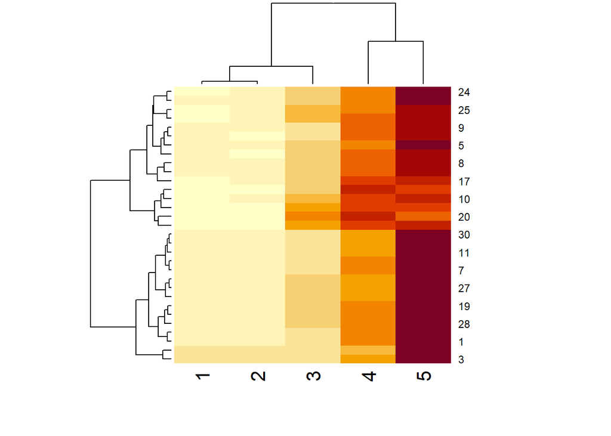

```r
heatmap(as.matrix(Oc_perc),keep.dendro = FALSE, margins = c(5,5))
```

# Pytania otwarte

## Do you think that the concerns expressed above can be addressed by applicable EU legislation If not do you think that there should be specific new rules for AI systems

Respondents clearly see the need for a new legislation specific for AI systems

```r
df <- as.data.frame(table(contr[,44]))
df
```

```
##                                      Var1 Freq
## 1                                          124
## 2 Current legislation is fully sufficient   32
## 3  Current legislation may have some gaps  355
## 4                              No opinion   45
## 5                                   Other  201
## 6   There is a need for a new legislation  459
```

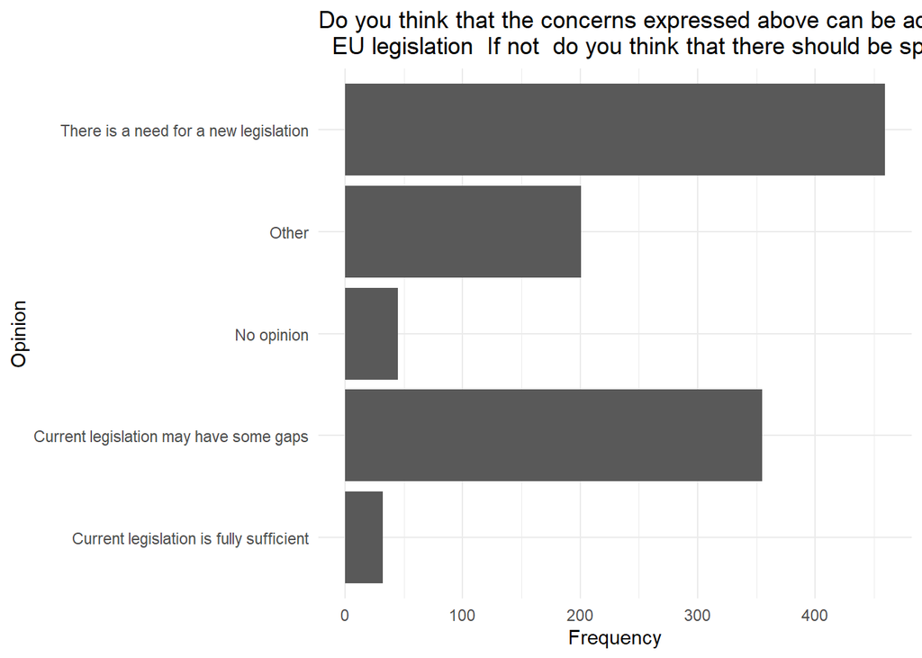

## “If you think that new rules are necessary for AI system do you agree that the introduction of new compulsory requirements should be limited to high risk applications where the possible harm caused by the AI system is particularly high”

Respondents are divided with tendency towards the support of the statement that new compulsory requirements should be limited to high risk applications

```r
df2 <- as.data.frame(table(contr[,46]))
df2
```

```
##         Var1 Freq
## 1             138
## 2         No  331
## 3 No opinion   68
## 4      Other  221
## 5        Yes  458
```

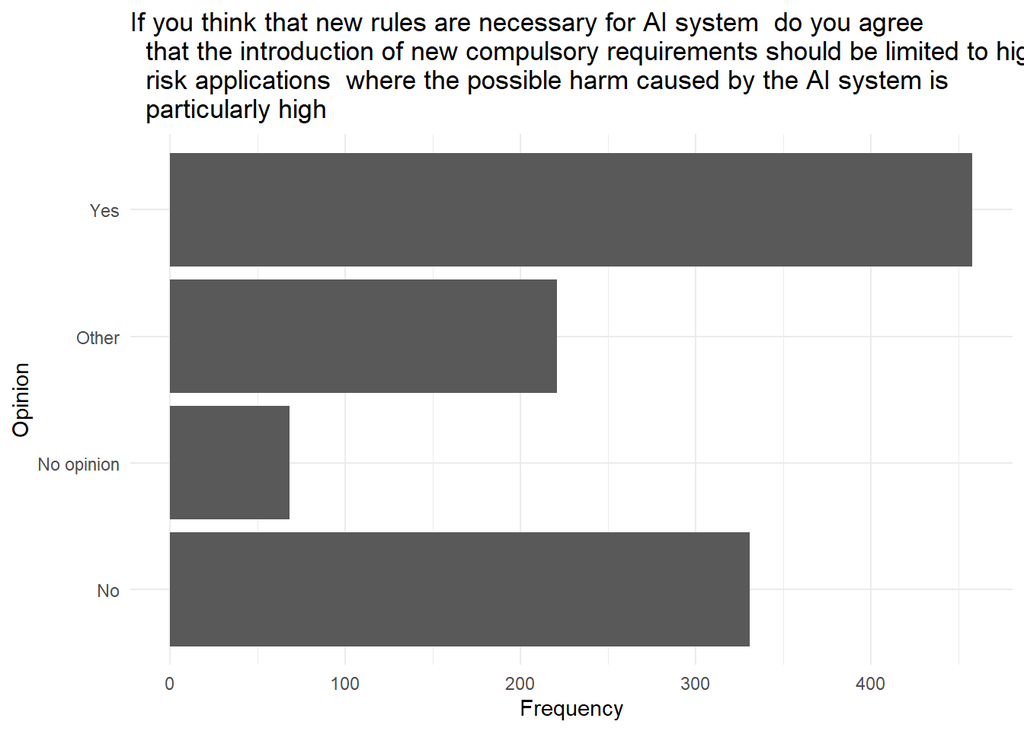

## “Do you agree with the approach to determine high risk AI applications proposed in Section 5 B of the White Paper”

Respondents agree with the approach to determine high risk AI application as in Section 5B of the White Paper

```r
df3 <- as.data.frame(table(contr[,48]))
df3
```

```
##         Var1 Freq
## 1             767
## 2         No   55
## 3 No opinion   49
## 4      Other   82
## 5        Yes  263
```

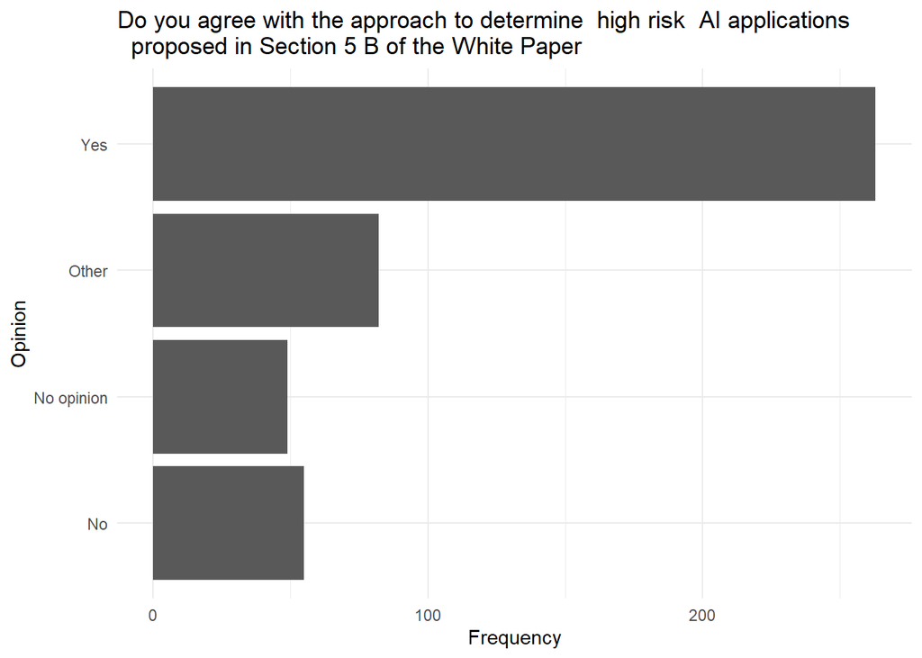

## “Do you think that the current national liability rules should be adapted for the operation of AI to better ensure proper compensation for damage and a fair allocation of liability”

Respondents agree that current nation liability rules should be adapted for the operation of AI

```r
df <- as.data.frame(table(contr[,70]))
df
```

```
##                                Var1 Freq
## 1                                    175
## 2                                No  130
## 3                        No opinion  252
## 4      Yes, for all AI applications  489
## 5 Yes, for specific AI applications  170
```

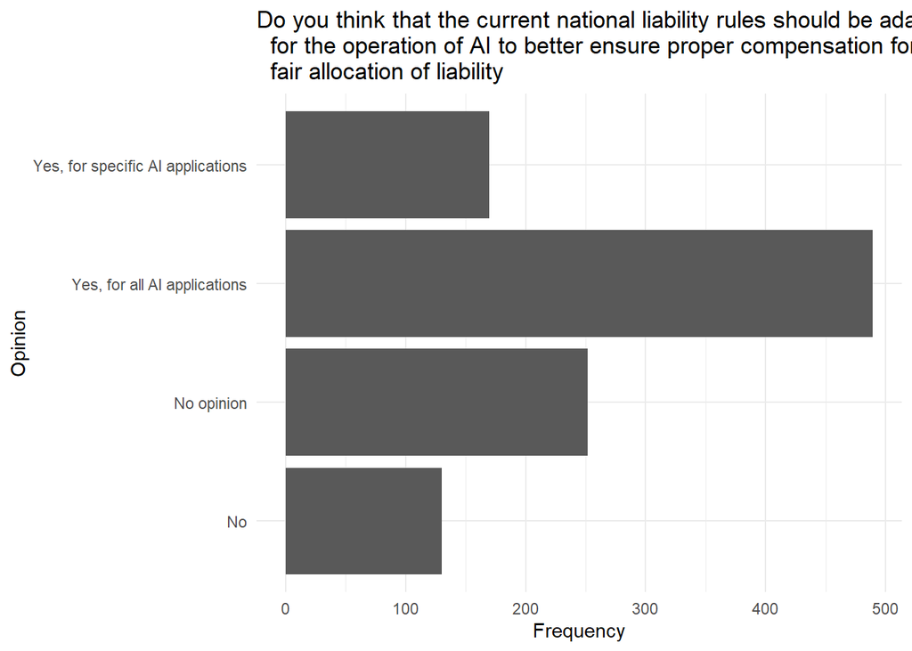

## “Do you think that the current EU legislative framework for liability Product Liability Directive should be amended to better cover the risks engendered by certain AI applications”

Respondents agree that current EU legislative framework should cover the risks endangered by certain AI apps better

```r
df <- as.data.frame(table(contr[,68]))
df
```

```
##         Var1 Freq
## 1             172
## 2         No  131
## 3 No opinion  280
## 4        Yes  633
```

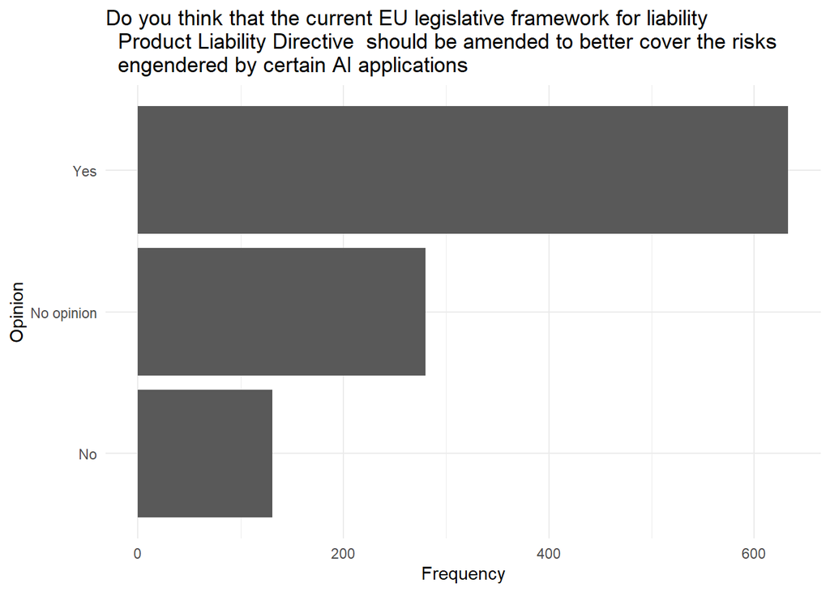

## “Do you think that the safety legislative framework should consider new risk assessment procedures for products subject to important changes during their lifetime”

```r
df <- as.data.frame(table(contr[,66]))
df
```

```
##         Var1 Freq
## 1             168
## 2         No   79
## 3 No opinion  166
## 4        Yes  803
```

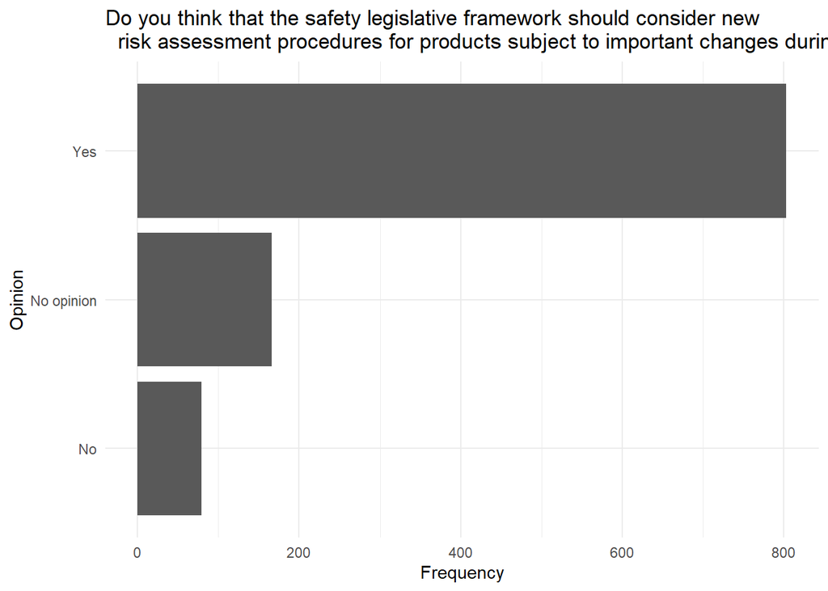

## “The current product safety legislation already supports an extended concept of safety protecting against all kind of risks arising from the product according to its use However which particular risks stemming from the use of artificial intelligence do you think should be further spelled out to provide more legal certainty”

Respondents points out that there should be provided more legal certainty inbthe area of Mental health risks and Personal security risks

```r
df <- as.data.frame(table(contr[,64]))
df
```

```
##                                        Var1 Freq
## 1                                            288
## 2                               Cyber risks   93
## 3                       Mental health risks  442
## 4                   Personal security risks  264
## 5 Risks related to the loss of connectivity  129
```

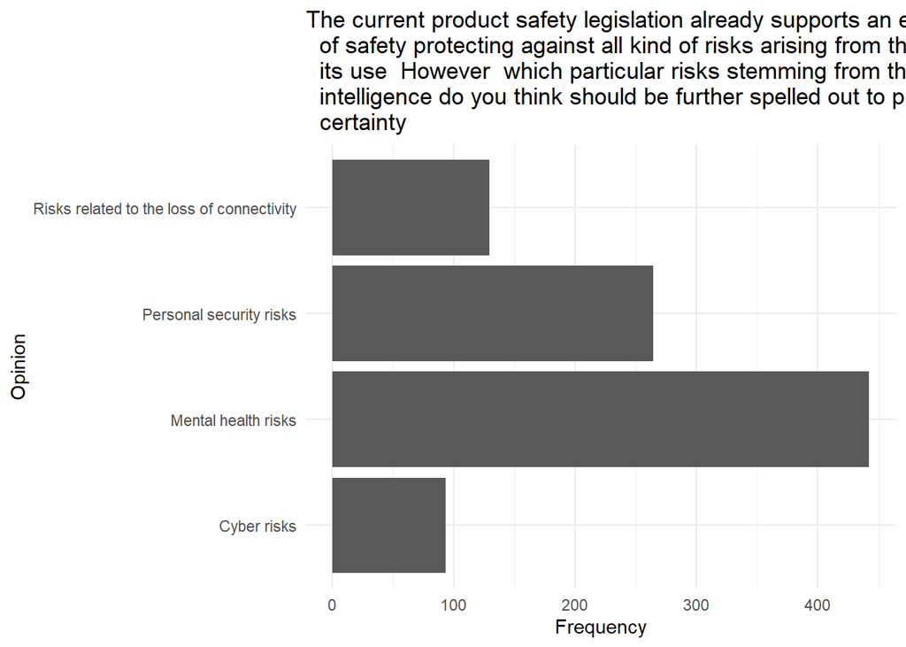

## “What is the best way to ensure that AI is trustworthy secure and in respect of European values and rules”

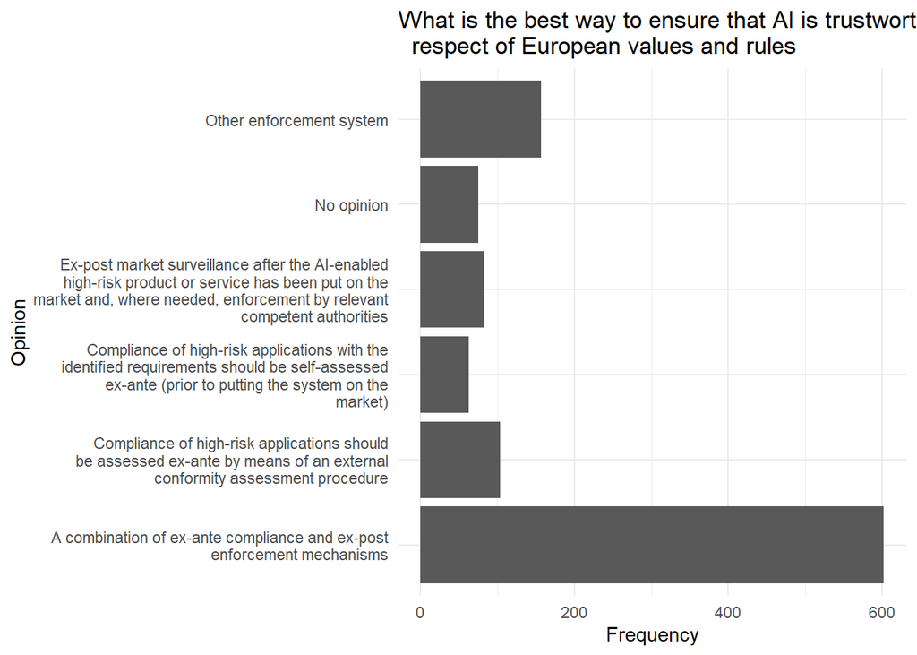

```r
df <- as.data.frame(table(contr[,61]))
df
```

[output not shown]

## “In addition to the existing EU legislation in particular the data protection framework including the General Data Protection Regulation and the Law Enforcement Directive or where relevant the new possibly mandatory requirements foreseen above see question above do you think that the use of remote biometric identification systems e g face recognition and other technologies which may be used in public spaces need to be subject to further EU level guidelines or regulation”

In the case of usage of remote biometric identification systems like face recognition the respondents were pretty inconclusive. Generally they are against its overwhelming presence, but it varies from the option of total ban on it by some certain cases to other ideas.

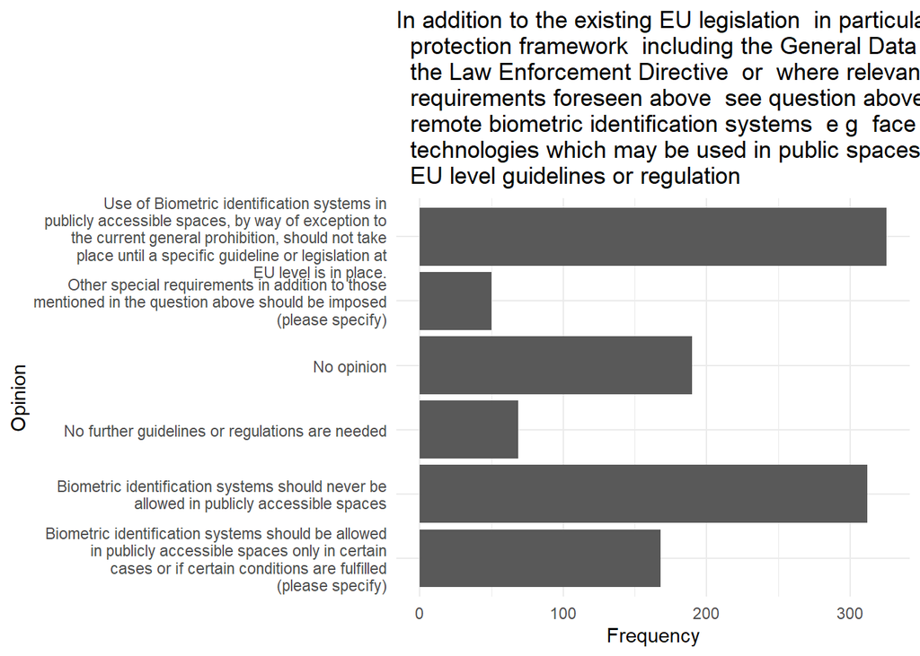

```r
df <- as.data.frame(table(contr[,57]))
df
```

[output not shown]